# final

## Weather Analysis

In this report we will be collecting data from Twitter with the keyword Weather and classify the tweet using the naive bayes algorithm to positive/negative tweets. In addition, a graphical libraries were used to visualize the classified data.

1. Retrieving the data
2. Classifying data
3. Testing data + (Cross-validation)
4. Curing data
5. Visualization

```python
import time

start = time.time() # to see how long will it take to run (Retrieving tweets not included)
print "Time Started"
```

```
Time Started
```

Load all the necessary libraries

```python
import tweepy #Twitter API library for Python
from pandas import DataFrame
from tweepy import OAuthHandler
from tweepy.streaming import StreamListener
from sklearn.feature_extraction.text import CountVectorizer
from pytagcloud import create_tag_image, make_tags
from pytagcloud.lang.counter import get_tag_counts
from guiqt import *
import csv
import re

# Setting up server login keys
consumer_key = '3Jbxdp7Egy3p5gYsCGW1N3jlu'
consumer_secret = 'zr0XYp30fFicsPVsya2LuO7MCLoxmHf2pbAKZCqkft4JZvTBGb'
access_token = '2382033235-3Lvy697WnSss8TYtwGHAmfYxi4TPzb8ONN2MPmD'
access_token_secret = 'ANQ3VAWY9nVEGVMeMR6pbgPaLXA97xXFFQDO0auqesTh7'
auth = tweepy.OAuthHandler(consumer_key, consumer_secret)
auth.set_access_token(access_token, access_token_secret)
api = tweepy.API(auth)
# %matplotlib inline
```

Testing the connection by requesting the holder of the account

```python
print api.me().name
```

```
Safar ALQAHTANI
```

Retrieve All tweets that has the word 'weather' in it. Due to the limitation of calls per user a sleep function will be activated when the limit has been exceeded (15 minutes). ReTweets has been filtered as well as non-english tweets and all filtered tweet will be saved alongside their location and time for later usage. FYI:It took more than 4 hours to acquire the weather dataset that will be demonstrated in this report.

### Retrieving the data

```python
# csvFile = open('weather.csv', 'a')
# retweets_re = re.compile(r'^RT\s')
# #Use csv Writer
# csvWriter = csv.writer(csvFile)
# # above omitted for brevity
# c = tweepy.Cursor(api.search,
#                            q="weather",
#                            since="2014-08-01",
#                            until="2014-10-05",
#                            lang="en").items()
# while True:
#     try:
#         tweet = c.next()
# #         print tweet.created_at
#         if re.search(retweets_re, tweet.text):
#             continue;
# #         print tweet.text
#         tweet.text = re.sub(r'\W+', ' ', tweet.text)
#         csvWriter.writerow([tweet.created_at,tweet.user.location.encode('utf-8'), tweet.text.encode('utf-8')])
#     except tweepy.TweepError:
#         time.sleep(60 * 15)
#         continue
#     except StopIteration:
#         break
```

### Classifying data

We have collected almost 16000 tweets about the weather from Twitter api. The next step is to teach the computer how to classify tweets, but one major issue that we do not have a set of classified data. All tweets that we acquired were unclassified, so we had to start classifying them.

According to Larry Wall, the original author of the Perl programming language, there are three great virtues of a programmer; Laziness, Impatience and Hubris.

Thats why we created an application that will help us classify the dataset.

```python
dataf = pd.read_csv('weather.csv', header=None)
if len(dataf.columns)>3: # if already classified set column Class
    dataf.columns=['CreatedAt', 'Location', 'Tweet', 'Class']
else:
    dataf.columns=['CreatedAt', 'Location', 'Tweet']
callClassi(dataf) # gui classifier + trainer
dataf.to_csv('weather.csv',header=None,index=False)
```

```python
from sklearn.externals import joblib
patz = 'pyqt/AutoClassifier.class'
clf = joblib.load(patz, mmap_mode='r')
```

Top ten identifier:

```python
clf.show_most_informative_features(10)
```

```
Most Informative Features
             contains(0) = True           Foreca : Negati =     60.7 : 1.0
            contains(10) = True           Foreca : Positi =     36.3 : 1.0
          contains(Rain) = True           Foreca : Negati =     34.2 : 1.0
             contains(1) = True           Foreca : Positi =     30.9 : 1.0
             contains(8) = True           Foreca : Positi =     28.2 : 1.0
             contains(4) = True           Foreca : Positi =     28.2 : 1.0
         contains(North) = True           Foreca : Positi =     22.8 : 1.0
             contains(3) = True           Foreca : Positi =     18.5 : 1.0
       contains(weather) = False          Foreca : Positi =     17.7 : 1.0
             contains(7) = True           Foreca : Positi =     17.5 : 1.0
```

It is time to classify the whole 15500 tweets, but first let's separate the classified data from the unclassified one and perform some feature extracting.

```python
dataTweet = pd.read_csv('pyqt/weather.csv', header=None)
dataTweet.columns=['CreatedAt', 'Location', 'Tweet', 'Class']

dataf = dataTweet.copy()
counter = 0
for i in range(len(dataf.Class)):
    if dataf.Class[i] == '?':
        counter = i
        break;
dataf = dataf[:counter]
lines_ = []
for i in range(counter):
    lines_.append([dataf.Tweet[i],dataf.Class[i]])
for i in range(len(lines_)):
    lines_[i] = (tokenizer.tokenize(lines_[i][0]), lines_[i][1])
word_features = get_word_features(get_words_in_tweets(lines_))
def extract_features(document):
    document_words = set(document)
    features = {}
    for word in word_features:
        features['contains(%s)' % word] = (word in document_words)
    return features
```

First visual test for the classifier. Taken from the dataset manually.

```python
sents1 = 'Barberton Oh Temp 41 6 F Wind 1 mph Dir WSW Baro Rising slowly Rain2day 0 03in Hum 70 UV 0 0 20 00 10 04 14 weather Ohio'
sents2 = 'This cold weather aint even kuul man'
sents3 = 'This fall weather feels hella good'
sents4 = ' sale Strathwood Brentwood 4 Piece All Weather Furniture Set 149 00 at http t co ebmAmH7aNm This http t co Sm79YbWQyz'
print clf.classify(extract_features(sents1.split()))
print clf.classify(extract_features(sents2.split()))
print clf.classify(extract_features(sents3.split()))
print clf.classify(extract_features(sents4.split()))
```

```
Forecast
Negative
Positive
Unknown
```

Classify all tweets and store them in column called Class. Also print how many pre-classified.

```python
test_tweet = dataTweet[dataTweet.Class=='?'].copy()
print len(dataTweet)-len(test_tweet), ' were classified manually'
test_tweet.Class = test_tweet.Tweet.apply(lambda x: clf.classify(extract_features(str(x).split())))
```

```
639  were classified manually
```

### Testing data + (Cross-validation)

Test the classifier against trained data.

```python
test_tweet_temp = dataTweet[dataTweet.Class!='?']
tested_tweet = test_tweet_temp.Tweet.apply(lambda x: clf.classify(extract_features(str(x).split())))
count = np.sum(np.where(tested_tweet == test_tweet_temp.Class, 1, 0))
```

Prints how many were classified correctly.

```python
print (count*100.0 / len(test_tweet_temp))
```

```
84.0375586854
```

Cross-validate the classified data to see how well will the classifier classify.

```python
from sklearn.cross_validation import KFold
import numpy
from sklearn.pipeline import Pipeline
from sklearn.naive_bayes import MultinomialNB
from sklearn.naive_bayes import BernoulliNB
from sklearn.feature_extraction.text import TfidfTransformer
import math

#Standard MultinomialNB
pipeline = Pipeline([
  ('vectorizer',  CountVectorizer()),
  ('classifier',  MultinomialNB()) ])
#TfidfTransformer + MultinomialNB
pipeline1 = Pipeline([
  ('count_vectorizer',   CountVectorizer(ngram_range=(1, 2))),
  ('tfidf_transformer',  TfidfTransformer()),
  ('classifier',         MultinomialNB()) ])
#BernoulliNB
pipeline2 = Pipeline([
  ('count_vectorizer',   CountVectorizer(ngram_range=(1, 2))),
  ('classifier',         BernoulliNB(binarize=0.0)) ])
data = dataTweet[dataTweet['Class']!='♏'].copy()
data = data.dropna()
data = data[:counter]
data = data.dropna()

data.Location = data.Location.astype(str)
# create and test folds
def folds(fucntionpipe, folds=8):
    k_fold = KFold(n=len(data), n_folds=folds)
    scores = []
    for train_indices, test_indices in k_fold:
        train_text = numpy.asarray(data.iloc[train_indices]['Tweet'])
        train_y    = numpy.asarray(data.iloc[train_indices]['Class'])

        test_text  = numpy.asarray(data.iloc[test_indices]['Tweet'])
        test_y     = numpy.asarray(data.iloc[test_indices]['Class'])
        test_num = len(test_text)
        fucntionpipe.fit(train_text, train_y)
        score = fucntionpipe.score(test_text, test_y)
        scores.append(score)
    score = sum(scores) / len(scores)
    return score,test_num
# 595 traning / 32 testing

# to print a table of scores
def tablescore():
    score1,test_num = folds(pipeline, 20) #MultinomialNB
    score2,test_num1 = folds(pipeline1, 20)
    score3,test_num2 = folds(pipeline2, 20)
    scores_array =[]
    def ro(so):
        return "%.2f" % round(so,2)
    labels_columns = ['Classifier','Accuracy', 'MisClassified', 'Correctly Classified']
    scores_array.append(['MultinomialNB',ro(score1), (ro((1.0-score1)*test_num)), ro(score1*test_num)])
    scores_array.append(['TfidfTransformer',ro(score2), ro(((1.0-score2)*test_num1)), ro(score2*test_num1)])
    scores_array.append(['BernoulliNB',ro(score3), ro(((1.0-score3)*test_num2)), ro(score3*test_num2)])
    scores_array = pd.DataFrame(scores_array, columns=labels_columns)
    return scores_array
tablescore()
```

|  | Classifier | Accuracy | MisClassified | Correctly Classified |
| --- | --- | --- | --- | --- |
| 0 | MultinomialNB | 0.44 | 17.50 | 13.50 |
| 1 | TfidfTransformer | 0.44 | 17.24 | 13.76 |
| 2 | BernoulliNB | 0.40 | 18.55 | 12.45 |

Since we stored tweets with their location it will be a waste not to use them, but unfortunately people can insert any name into the location for example we found one of the location was 'hell'. To avoid getting errors we searched for a dataset that has the name of all the countries and the Latitude/Longitude positions. After good amount of searching we found a perfect match from developers.google.com.

```python
worlds = pd.read_csv('worlds.csv')
#obtianed from https://developers.google.com/public-data/docs/canonical/countries_csv
```

Glimpse of the worlds dataset

```python
worlds.head(10)
```

|  | CountryCode | Latitude | Longitude | CountryName |
| --- | --- | --- | --- | --- |
| 0 | AD | 42.546245 | 1.601554 | Andorra |
| 1 | AE | 23.424076 | 53.847818 | United Arab Emirates |
| 2 | AF | 33.939110 | 67.709953 | Afghanistan |
| 3 | AG | 17.060816 | -61.796428 | Antigua and Barbuda |
| 4 | AI | 18.220554 | -63.068615 | Anguilla |
| 5 | AL | 41.153332 | 20.168331 | Albania |
| 6 | AM | 40.069099 | 45.038189 | Armenia |
| 7 | AN | 12.226079 | -69.060087 | Netherlands Antilles |
| 8 | AO | -11.202692 | 17.873887 | Angola |
| 9 | AQ | -75.250973 | -0.071389 | Antarctica |

### Curing data

Drop rows with no location.

```python
dataTweet = dataTweet.dropna()
```

Convert location from twitter dataset and country name from the worlds dataset to string to avoid unwanted warning/errors.

```python
dataTweet.Location = dataTweet.Location.astype(str)
worlds.CountryName = worlds.CountryName.astype(str)
```

difflib is a good library to compare strings and also find differences.

```python
from difflib import SequenceMatcher
m = SequenceMatcher(None, "SAFAR".lower(), "safar")
m.ratio()
```

```
1.0
```

Using the function above we were able to create a function that will take a name as an argument try to find a match against the worlds dataset. It will return the closest match rate and the index of the its country.

```python
def findMatch(city):
    rate = 0.0
    city_index = -1
    city_array = city.lower().split(',')
    for ix, row in worlds.iterrows():
        for i in city_array:
            m = SequenceMatcher(None, row.CountryName.lower(), i).ratio()
            if (m > rate):
                rate = m
                city_index = ix
    if city_index != -1:
        if worlds.CountryName[city_index] == 'USA':
            city_index = worlds.index[worlds.CountryName=='United States'].values[0]
    return rate, city_index
```

## Visualization

We used a great library called pytagcloud which provide functions to take a simple text and produce a cool image which represent the frequency of each word. createWordCup is a function that will help to transform our dataset into a simple string that has the most important words in such a way that it will work with pytagcloud library.

```python
def createWordCup(datato, filename, freq):
    docs = datato.Tweet.tolist()
    vect = CountVectorizer(min_df=0., max_df=1.0)
    X = vect.fit_transform(docs)
    alldata = DataFrame(X.A, columns=vect.get_feature_names())
    str1 =' '
    for i in alldata:
        if len(i)>3 and i.lower()!='weather' and i.lower()!='http':
            if alldata[i].sum() > freq:
                temp_str = str(i)+' '
                str1+= temp_str*alldata[i].sum()

    tags = make_tags(get_tag_counts(str1), maxsize=120)
    create_tag_image(tags, 'pyqt/'+filename+'.png', size=(900, 600), fontname='Lobster')
```

Creating tags for the classifier dataset only.

```python
createWordCup(dataf, 'classifiyed', 8)
```

[figure not shown]

```python
createWordCup(dataTweet, 'all', 50)
```

[figure not shown]

Now we are extracting the latitude and longitude from the tweets (Positive/Negative only) using our match function.

```python
holl = {}
for ix, row in dataTweet.iterrows():
    if(row.Class == 'Negative' or row.Class=='Positive'):
        rate, city_idx = findMatch(row.Location)
        if(rate > 0.75):
            if city_idx not in holl:
                holl[city_idx] = []
            holl[city_idx].append(row.Class)

#         print worlds.CountryName[city_idx] +'  ' +dataTweet.Location[ix]
```

Obtaining the most dominant opinion about weather in each country.

```python
aphight = []
for key, value in holl.iteritems():
    pos = 0.0
    neg = 0.0
    for i in value:
        if i == 'Negative':
            neg+=1
        else:
            pos+=1
    total = (pos+neg)
    mode_weather = ''
    if pos > neg:
        mode_weather='Positive'
    elif pos < neg:
        mode_weather='Negative'
    else:
        mode_weather='Neutral'

    aphight.append([key,mode_weather, pos/total, neg/total])
```

Plotting the positions using a map provided by the library called Basemap.

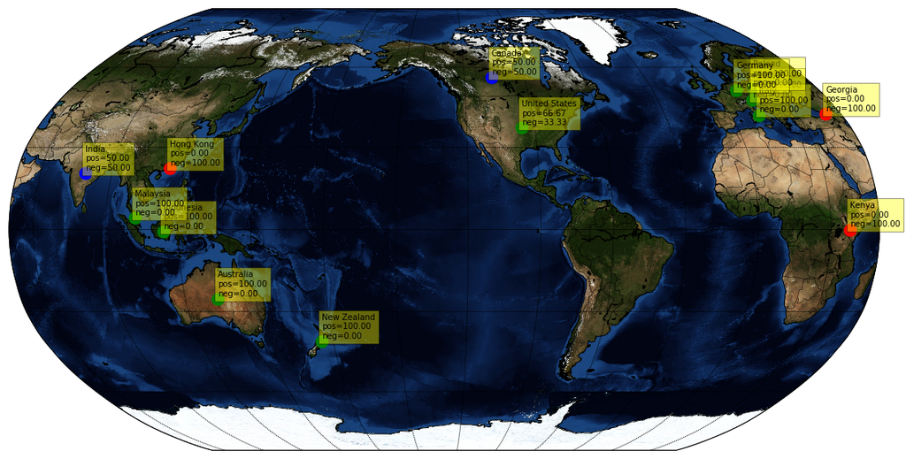

```python
%matplotlib inline
from pylab import rcParams

rcParams['figure.figsize'] = (50,10)
from mpl_toolkits.basemap import Basemap
import matplotlib.pyplot as plt
import numpy as np
#run once only
if 'mapB' not in locals(): # do not load the map(slow) twice if execute this block of code more than one
    mapB = Basemap(projection='robin', resolution = 'l', area_thresh = 1000.0,
              lat_0=0, lon_0=-130)
mapB.drawcoastlines()
mapB.drawcountries()
#     mapB.fillcontinents()
mapB.bluemarble()
mapB.drawmapboundary()
mapB.drawmeridians(np.arange(0, 360, 30))
mapB.drawparallels(np.arange(-90, 90, 30))


def get_marker_color(classifi):
    if classifi == 'Positive':
        return ('go') # green
    elif classifi == 'Negative':
        return ('ro') # red
    else:
        return ('bo') # blue
for i in aphight:
    x,y = mapB(worlds.Longitude[i[0]], worlds.Latitude[i[0]])
    mapB.plot(x,y, get_marker_color(i[1]), markersize=15 )
    plt.text(x, y+100000, worlds.CountryName[i[0]].decode('utf-8')+'\npos='+"%0.2f" % (i[2]*100)+'\nneg='+"%0.2f" % (i[3]*100) ,
    bbox=dict(facecolor='yellow', alpha=0.4),fontsize=10)
plt.show()
```

```python
end = time.time()
print str((end - start)/60.0) + ' Minutes'
```

```
9.66788210074 Minutes
```